# Delomys Data Analysis

Antonio Escallón

12/25/2022

# Demolys Data Analysis

## Data Exploration

### Demolys Data:

Here, we will be loading the Demolys Data and producing a summary of the body mass and body length data columns.

```
## here() starts at /Users/antonioescallon23/Documents/GitHub/Educational-projects
```

```
##   observation   genus         binomial body_mass body_length   age    sex
## 1       27526 Delomys Delomys dorsalis      50.5         259 adult female
## 2       27528 Delomys Delomys dorsalis      79.0         223 adult female
## 3       27529 Delomys Delomys dorsalis      57.0         206 adult female
## 4       27530 Delomys Delomys dorsalis      71.0         229 adult   male
## 5       27533 Delomys Delomys dorsalis      56.0         105 adult   male
## 6       27534 Delomys Delomys dorsalis      50.0         118 adult   male
##   longitude  latitude status
## 1 -48.22950 -24.20256  alive
## 2 -48.22950 -24.20256  alive
## 3 -48.22950 -24.20256  alive
## 4 -48.22950 -24.20256  alive
## 5 -50.39215 -29.40807  alive
## 6 -50.39215 -29.40807   dead
```

```
##    Min. 1st Qu.  Median    Mean 3rd Qu.    Max.
##    5.00   35.00   43.00   44.06   54.00  105.00
```

```
##    Min. 1st Qu.  Median    Mean 3rd Qu.    Max.
##    49.0   106.0   116.0   114.7   124.0   265.0
```

We will now perform a test of normality on the body mass and length columns using the shapiro test

```
## $body_length
##
##  Shapiro-Wilk normality test
##
## data:  newX[, i]
## W = 0.87609, p-value < 2.2e-16
##
##
## $body_mass
##
##  Shapiro-Wilk normality test
##
## data:  newX[, i]
## W = 0.99506, p-value = 4.33e-05
```

### Graphical Exploration

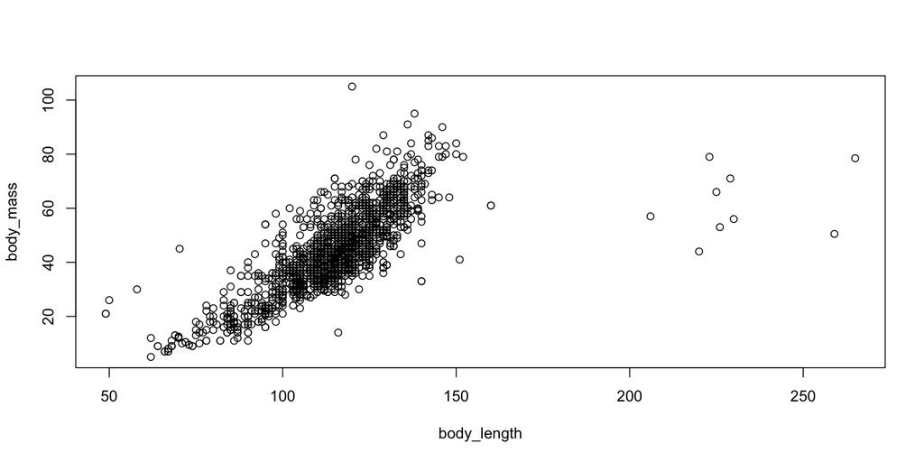

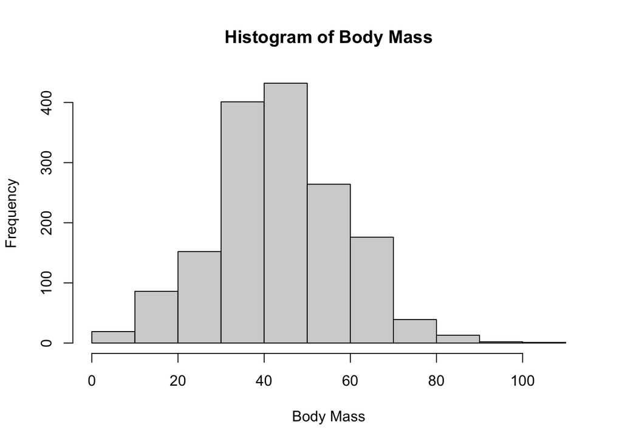

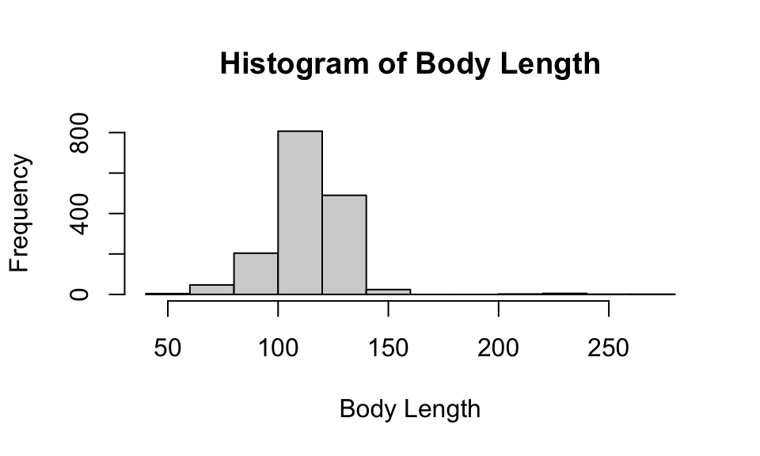

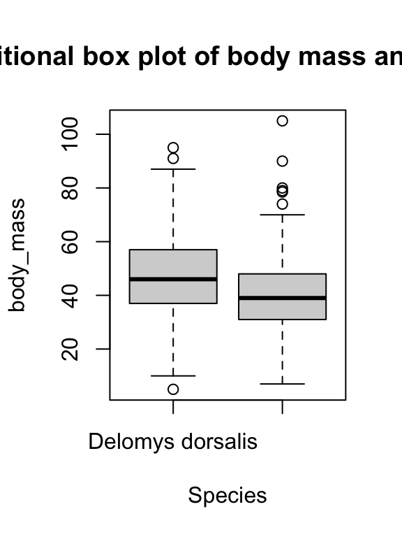

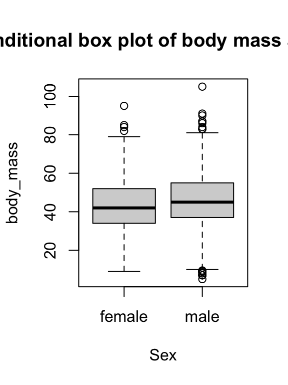

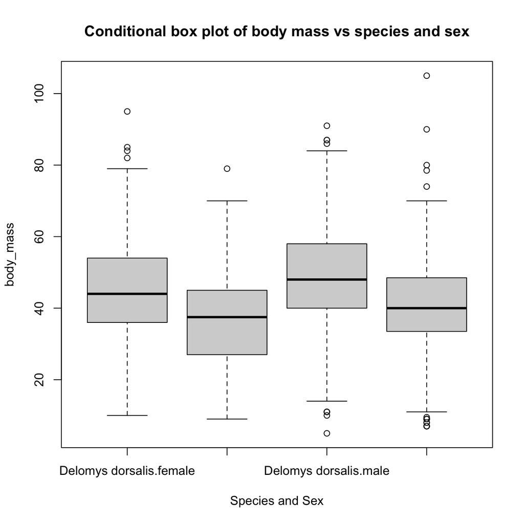

### Questions 1-4

- **Q1 (2 pts.): Qualitatively describe the relationship between body mass and length.**
  - Does the relationship seem linear, curved, nonexistent?
  - With the exception of some outliers, the relationship between body mass and length is clearly positively linear. By this I mean that the the more length we have the heavier we can expect animal to be.
- **Q2 (2 pts.): Qualitatively describe the shapes of the histograms.**
  - Do the data appear normally-distributed? Explain why or why not.
  - Explain why we care (or not) whether the data are normally distributed.
  - The body mass histogram is normally distributed with a slight skew towards the right, meaning that most of the species is on the lighter side. The body length histogram is a lot less normally distributed, with a more aggressive skewing towards the right and a couple of real longer outliers in our data. Normal distribution in our data makes make the distribution explanation very easy since we only need the mean and the standard deviations to do so. In addition to making it easy to explain, it also makes it easy to preduct when using other models.
- **Q3 (2 pts.): Using both the histograms and normality tests, do you think the (unconditioned) body masses and body length are normally-distributed?**
  - Make sure you contrast your visual assessment of normality to the results of the numerical normality tests.
  - If our null hypothesis is for normality, than both of the two histograms can reject the null hypothesis since they are both lower than 5%. That being said, there is a big difference between both. The body length histogram is not really normal and that is shown both by its shape and its low p value. In comparison, the body mass histogram has a much higher p value and, if we squint hard, could pass as a normal distribution graph.
- **Q4 (2 pts.): Examine the three conditional boxplots.**
  - Describe any graphical evidence you see for body mass differences based on species and/or sex.
  - Dorsalis is the heavier species overall, and males in both species are the heaviest. I think whats most interesting is the number of outliers there are in both male species, and going even further, the number of outlines in the Delomys male species. It really makes me want to look further into why there are so many outliers in that species branch of animals.

## Model Building

### Creaitng Models 1-5:

#### Model Diagnostics

We will now evaluate the assumption of normality of the models residuals by first having a graphical approach

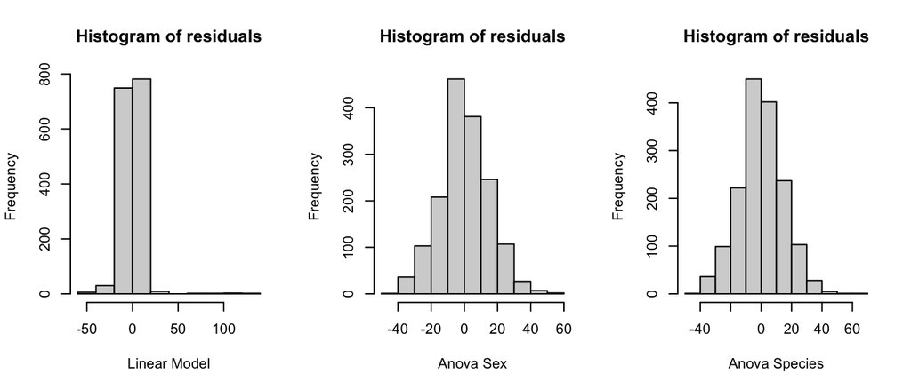

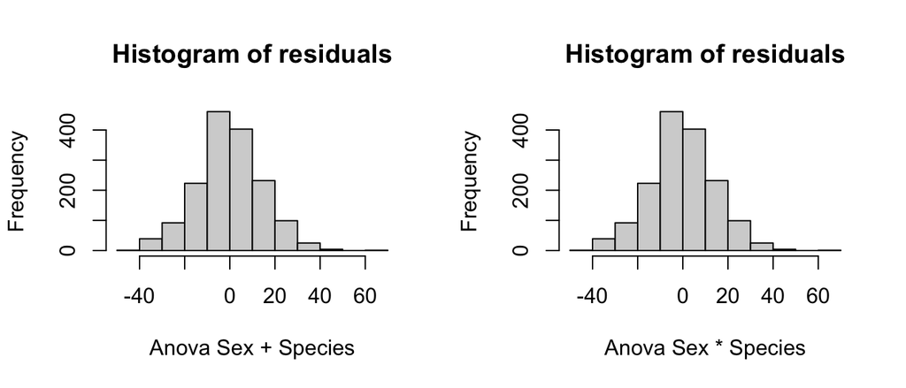

```r
#Next we will use the shapiro test to see if we can reject our null hypothesis of the normality of residuals
shapiro.test(residuals(fit1))
```

```
##
##  Shapiro-Wilk normality test
##
## data:  residuals(fit1)
## W = 0.73462, p-value < 2.2e-16
```

```r
shapiro.test(residuals(fit2))
```

```
##
##  Shapiro-Wilk normality test
##
## data:  residuals(fit2)
## W = 0.99563, p-value = 0.0001541
```

```r
shapiro.test(residuals(fit3))
```

```
##
##  Shapiro-Wilk normality test
##
## data:  residuals(fit3)
## W = 0.99535, p-value = 8.103e-05
```

```r
shapiro.test(residuals(fit4))
```

```
##
##  Shapiro-Wilk normality test
##
## data:  residuals(fit4)
## W = 0.99525, p-value = 6.805e-05
```

```r
shapiro.test(residuals(fit5))
```

```
##
##  Shapiro-Wilk normality test
##
## data:  residuals(fit5)
## W = 0.99526, p-value = 6.816e-05
```

### Questions 5-6 Model Assumptions

- **Q5 (2 pts.): What do you conclude about residual normality based on the numerical and graphical diagnostics?**
  - Its interesting what happens to my answer when I look at both the graphical and numerical diagnostics. At first glance, I would argue that only the linear model is the one that doesn’t reside within the realm of data normality. The other graphs, especially both Two-Anova graphs really give a normal distribution feel to them. That being said, when we look at the p values of each, it is clear that fit2 is the one that gets the closest to normality since its p value is closest to 5%. Upon further analysis, I can see that fit2 is the one with the least amount of residuals and a good chunk of its data gravitating towards the “center” of the graph. That being said, all of the graphs would reject the null hypothesis.
- **Q6 (1 pt.): Are violations of the normality assumption equally severe for all the models?**
  - They are not. As explained above, there is one true graph that really does not look normal, and the others could wear a coat and get past security.

### Model Interpretation

```r
knitr::kable(coef(summary(fit1)), digits=3)
```

|  | Estimate | Std. Error | t value | Pr(>\|t\|) |
| --- | --- | --- | --- | --- |
| (Intercept) | 76.125 | 0.916 | 83.123 | 0 |
| body_mass | 0.875 | 0.020 | 44.463 | 0 |

```r
knitr::kable(coef(fit2), digits=3)
```

|  | x |
| --- | --- |
| (Intercept) | 42.711 |
| sexmale | 2.784 |

```r
knitr::kable(coef(fit3), digits=3)
```

|  | x |
| --- | --- |
| (Intercept) | 46.752 |
| binomialDelomys sublineatus | -7.683 |

```r
knitr::kable(coef(fit4), digits=3)
```

|  | x |
| --- | --- |
| (Intercept) | 45.070 |
| sexmale | 3.795 |
| binomialDelomys sublineatus | -8.193 |

```r
knitr::kable(coef(fit5), digits=3)
```

|  | x |
| --- | --- |
| (Intercept) | 45.055 |
| sexmale | 3.828 |
| binomialDelomys sublineatus | -8.142 |
| sexmale:binomialDelomys sublineatus | -0.095 |

```r
knitr::kable(anova(fit2), digits=3)
```

|  | Df | Sum Sq | Mean Sq | F value | Pr(>F) |
| --- | --- | --- | --- | --- | --- |
| sex | 1 | 3061.678 | 3061.678 | 13.943 | 0 |
| Residuals | 1578 | 346507.131 | 219.586 | NA | NA |

```r
knitr::kable(anova(fit3), digits=3)
```

|  | Df | Sum Sq | Mean Sq | F value | Pr(>F) |
| --- | --- | --- | --- | --- | --- |
| binomial | 1 | 21289.68 | 21289.680 | 102.075 | 0 |
| Residuals | 1583 | 330164.45 | 208.569 | NA | NA |

```r
knitr::kable(anova(fit4), digits=3)
```

|  | Df | Sum Sq | Mean Sq | F value | Pr(>F) |
| --- | --- | --- | --- | --- | --- |
| sex | 1 | 3061.678 | 3061.678 | 14.958 | 0 |
| binomial | 1 | 23727.134 | 23727.134 | 115.923 | 0 |
| Residuals | 1577 | 322779.997 | 204.680 | NA | NA |

```r
knitr::kable(anova(fit5), digits=3)
```

|  | Df | Sum Sq | Mean Sq | F value | Pr(>F) |
| --- | --- | --- | --- | --- | --- |
| sex | 1 | 3061.678 | 3061.678 | 14.949 | 0.00 |
| binomial | 1 | 23727.134 | 23727.134 | 115.850 | 0.00 |
| sex:binomial | 1 | 0.791 | 0.791 | 0.004 | 0.95 |
| Residuals | 1576 | 322779.206 | 204.809 | NA | NA |

### Questions 7-9: Simple linear Regression

- **Q7 (2 pts.): What is the magnitude of the mass/length relationship?**
  - There is a strong magnitude of the mass/length relationship, which means we can closley predict the mass of an animal witht a provided length

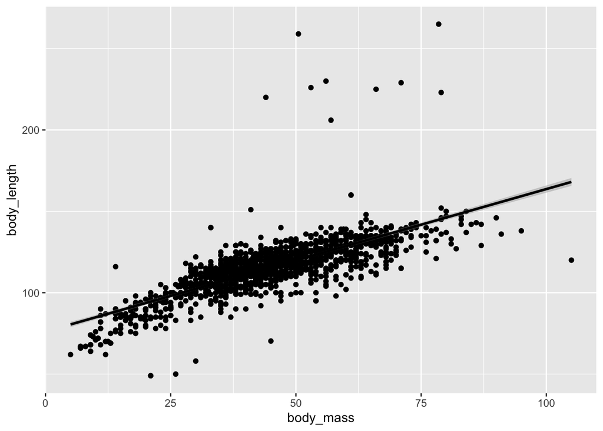

- **Q8 (2 pts.): What is the expected body length of an animal that weighs 100g?**
  - From the graph above and our previous numerical analysis we can see that the length of the animal will be ~163 when the body mass is 100g
- **Q9 (2 pts.): What is the expected body length of an animal that weighs 0g?**
  - Its hard to get the y-intercept from the graph, but we can go back to the table we created and see that the value will be of 76.125

### Questions 10-13: Body Mass: Coefficient Tables

```r
knitr::kable(coef(fit2), digits=3)
```

|  | x |
| --- | --- |
| (Intercept) | 42.711 |
| sexmale | 2.784 |

```r
knitr::kable(coef(fit3), digits=3)
```

|  | x |
| --- | --- |
| (Intercept) | 46.752 |
| binomialDelomys sublineatus | -7.683 |

```r
knitr::kable(coef(fit4), digits=3)
```

|  | x |
| --- | --- |
| (Intercept) | 45.070 |
| sexmale | 3.795 |
| binomialDelomys sublineatus | -8.193 |

```r
knitr::kable(coef(fit5), digits=3)
```

|  | x |
| --- | --- |
| (Intercept) | 45.055 |
| sexmale | 3.828 |
| binomialDelomys sublineatus | -8.142 |
| sexmale:binomialDelomys sublineatus | -0.095 |

- **Q10 (1 pt.): What is the base level for sex?**
  - 42.711
- **Q11 (1 pt.): What is the base level for binomial?**
  - 46.752
- **Q12 (1 pt.): Which sex is heavier? How do you know?**
  - The male sex from the provided sexmale variable in the coefficient table of the fit4 model.
- **Q13 (1 pt.): Which species is heavier? How do you know?**
  - The Dorsalis species is heavier. We know this from the negative variable given to the sublineatus speciesprovided by the coefficient table of the fit5 model.

### Questions 14-16: ANOVA Tables

```r
knitr::kable(anova(fit2), digits=3)
```

|  | Df | Sum Sq | Mean Sq | F value | Pr(>F) |
| --- | --- | --- | --- | --- | --- |
| sex | 1 | 3061.678 | 3061.678 | 13.943 | 0 |
| Residuals | 1578 | 346507.131 | 219.586 | NA | NA |

```r
knitr::kable(anova(fit3), digits=3)
```

|  | Df | Sum Sq | Mean Sq | F value | Pr(>F) |
| --- | --- | --- | --- | --- | --- |
| binomial | 1 | 21289.68 | 21289.680 | 102.075 | 0 |
| Residuals | 1583 | 330164.45 | 208.569 | NA | NA |

```r
knitr::kable(anova(fit4), digits=3)
```

|  | Df | Sum Sq | Mean Sq | F value | Pr(>F) |
| --- | --- | --- | --- | --- | --- |
| sex | 1 | 3061.678 | 3061.678 | 14.958 | 0 |
| binomial | 1 | 23727.134 | 23727.134 | 115.923 | 0 |
| Residuals | 1577 | 322779.997 | 204.680 | NA | NA |

```r
knitr::kable(anova(fit5), digits=3)
```

|  | Df | Sum Sq | Mean Sq | F value | Pr(>F) |
| --- | --- | --- | --- | --- | --- |
| sex | 1 | 3061.678 | 3061.678 | 14.949 | 0.00 |
| binomial | 1 | 23727.134 | 23727.134 | 115.850 | 0.00 |
| sex:binomial | 1 | 0.791 | 0.791 | 0.004 | 0.95 |
| Residuals | 1576 | 322779.206 | 204.809 | NA | NA |

### Q17-18: Model Comparison

```r
#Calculating the AIC
AIC(fit1)
```

```
## [1] 12291.67
```

```r
AIC(fit2)
```

```
## [1] 13006.8
```

```r
AIC(fit3)
```

```
## [1] 12966.36
```

```r
AIC(fit4)
```

```
## [1] 12896.73
```

```r
AIC(fit5)
```

```
## [1] 12898.72
```